# Categorical class 7

# Packages

```r
library(haven)      # read in SPSS data
library(ggplot2)    # plots
theme_set(theme_classic(base_size = 16)) # Set ggplot theme and increase font
library(dplyr)      # data manipulation
library(lmtest)     # LR tests
library(kableExtra) # prettier tables in HTML
library(modglm)     # interactions in GLiMs
library(boot)       # bootstrapping
```

# Data

- Simulated data from Coxe, S., West, S. G., & Aiken, L. S. (2009). The analysis of count data: A gentle introduction to Poisson regression and its alternatives. *Journal of Personality Assessment, 91(2)*, 121-136.
  - `case`: Subject ID
  - `sensation`: Sensation seeking (1 to 7)
  - `gender`: 0 = female, 1 = male
  - `y`: Number of alcoholic beverages consumed on Saturday night

```r
jpa <- read_sav("jpapoisson.sav")
head(jpa, n = 10)
```

```
# A tibble: 10 × 4
    case sensation gender     y
   <dbl>     <dbl>  <dbl> <dbl>
 1     1      6.06      1     4
 2     2      5.31      1     4
 3     3      3.94      1     1
 4     4      4.30      1     6
 5     5      5.58      1     0
 6     6      4.89      1     8
 7     7      4.51      0     6
 8     8      6.16      0     1
 9     9      4.19      1     7
10    10      5.64      1     8
```

## Outcome

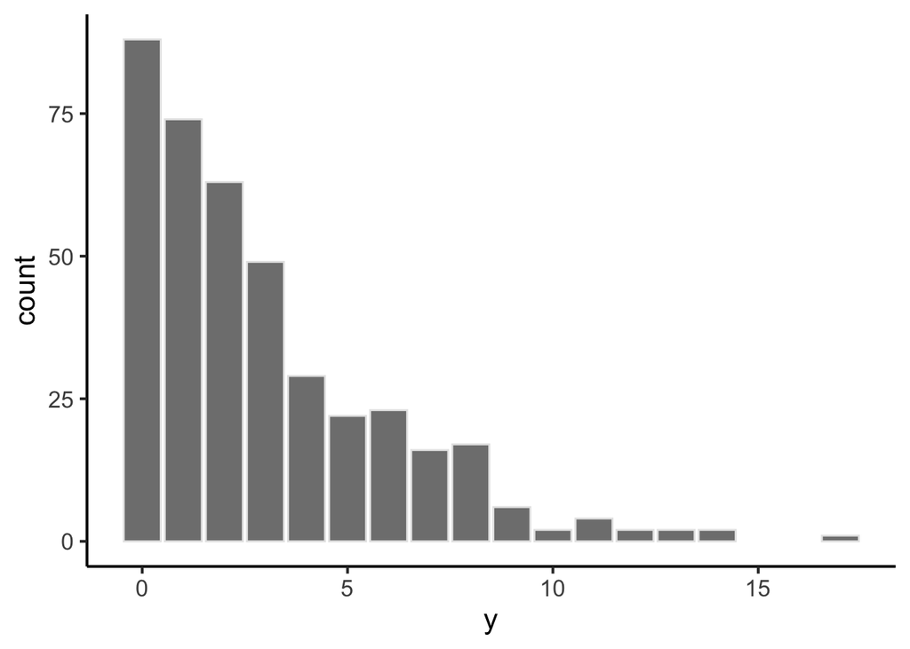

```r
ggplot(data = jpa, aes(x = y)) +
    geom_bar(fill = "grey50", color = "grey90")
```

- The mean is 2.93
- The variance is 8.832

```r
jpa <- jpa %>%
    mutate(sensation4 = sensation - 4)
```

- Center `sensation` at a value of 4

# Interactions

## Step 1. Do we need a product term?

- Run models with and without a product term
  - Compare using LR test

```r
m1 <- glm(y ~ sensation4 + gender,
          family = poisson(link = "log"),
          data = jpa)
m2 <- glm(y ~ sensation4 + gender + sensation4*gender,
          family = poisson(link = "log"),
          data = jpa)
lrtest(m1, m2)
```

```
Likelihood ratio test

Model 1: y ~ sensation4 + gender
Model 2: y ~ sensation4 + gender + sensation4 * gender
  #Df LogLik Df  Chisq Pr(>Chisq)
1   3 -941.4
2   4 -938.4  1 5.9874    0.01441 *
---
Signif. codes:  0 '***' 0.001 '**' 0.01 '*' 0.05 '.' 0.1 ' ' 1
```

- The test is significant
  - Use the more complex model (`m2`) with a product term

```r
summary(m2)
```

```
Call:
glm(formula = y ~ sensation4 + gender + sensation4 * gender,
    family = poisson(link = "log"), data = jpa)

Deviance Residuals:
    Min       1Q   Median       3Q      Max
-3.4817  -1.7195  -0.5326   0.8161   3.7184

Coefficients:
                  Estimate Std. Error z value Pr(>|z|)
(Intercept)        0.46454    0.10909   4.258 2.06e-05 ***
sensation4         0.10318    0.07412   1.392   0.1639
gender             0.55540    0.12950   4.289 1.80e-05 ***
sensation4:gender  0.21434    0.08694   2.465   0.0137 *
---
Signif. codes:  0 '***' 0.001 '**' 0.01 '*' 0.05 '.' 0.1 ' ' 1

(Dispersion parameter for poisson family taken to be 1)

    Null deviance: 1186.76  on 399  degrees of freedom
Residual deviance:  953.47  on 396  degrees of freedom
AIC: 1884.8

Number of Fisher Scoring iterations: 5
```

## Step 2. Marginal effect

- There’s not a *single* marginal effect (i.e., $b_3$)
  - The marginal effect depends on the predictor(s)
  - It is **conditional** on the predictor(s)

### `modglm()` inputs

- `modglm()` function in **modglm** package
  - `model` = the model you want to use (`m2` above)
  - `vars` = the variables in the model
    - Don’t include the product term
    - Remember the model doesn’t have to have a product term
  - `data` = the data used to estimate the model
  - `type` = type of interaction (i.e., the predictors)
    - `cpd` for continuous by continuous
    - `fd` for continuous by categorical
    - `dd` for categorical by categorical
  - `hyps` = values of predictors to get interaction effects for
    - Default is `"means"` of each variable
    - Can also select specific values of `sensation4` and `gender`
      - e.g.: `hyps = c(1, 2, 0)`
        - `1` = intercept
        - `2` = `sensation4` equal to 2 (`sensation` = 6)
        - `0` = `gender` equal to 0 (female)

```r
ints<-modglm(model=m2,
             vars=c("sensation4","gender"),
             data=jpa,
             type="fd",
             hyps="means")
```

### `modglm()` outputs

- `obints`: data frame with values for each observation (case)
  - `int.est` = interaction estimate for that observation
  - `hat` = predicted outcome value
  - `se.int.est` = standard error of the interaction
  - `t.val` = $t$-statistic (i.e., estimate / standard error)
  - `sig` = whether the $t$ statistic is significant (i.e., is there a significant interaction effect?)

```r
head(ints$obints)
```

```
    int.est      hat se.int.est    t.val  sig
1 1.4883021 5.326550  0.3426059 4.344064 Sig.
2 1.1447569 4.196942  0.2376866 4.816245 Sig.
3 0.7003903 2.719653  0.1263199 5.544578 Sig.
4 0.7987105 3.048734  0.1479351 5.399060 Sig.
5 1.2620919 4.583668  0.2720132 4.639818 Sig.
6 0.9895459 3.683558  0.1950928 5.072179 Sig.
```

- `inthyp` = interaction effect for hypothesized values in `hyps`
  - `int.est` = interaction estimate for that observation
  - `hat` = predicted outcome value
  - `se.int.est` = standard error of the interaction
  - `t.val` = $t$-statistic (i.e., estimate / standard error)

```r
ints$inthyp
```

```
$int.est
[1] 1.096701

$hat
[1] 2.672864

$se.int.est
[1] 0.2241368

$t.val
[1] 4.893
```

- `prop.sig` = proportion of observations for whom the interaction is significant
  - Here, all of them
  - The instantaneous slopes are different between men and women for all observed values of `sensation4`
- This is kind of similar to Johnson-Neyman approach to interactions
  - Where are the two slopes different?
  - In this case, for all values of `sensation4` in the sample

```r
ints$prop.sig
```

```
[1] 1
```

- `intsplot` = plot of interaction effect (Y) vs predicted outcome value (X)
  - Points are colored by whether the interaction is significant
    - All observations show a significant interaction effect here
    - See McCabe et al. (2020), Figure 4 for an example where that’s not true
- Note that you get two lines here because the moderator is *binary* (`gender`)
- I’m not really 100% sure what to do with this plot
  - It might be more informative if the interaction weren’t significant for everyone?

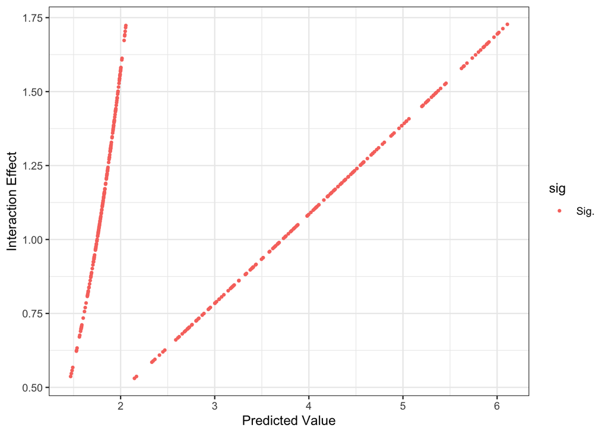

```r
ints$intsplot
```

### `margplot()` function from **modglm**

- This function should make a nice plot
  - But it doesn’t work for me with this dataset
  - It does work with the example data from the package, so I’m not sure what’s going on

```r
p<-margplot(model=m1,
            vars=c("sensation4","gender"),
            foc="sensation4",
            mod="gender",
            modlevels=c(0,1),
            data=jpa,
            hyps="means",
            sm=F)
```

### Plots

#### Plot 1: Plot of data with separate lines for each group

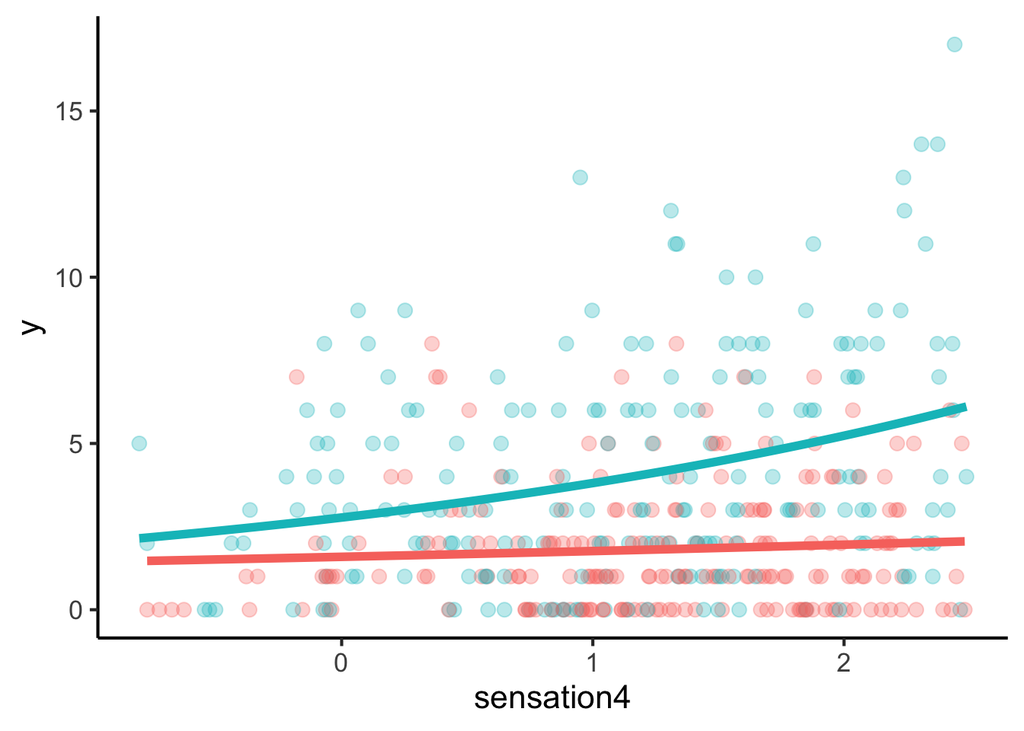

```r
ggplot(data = jpa, aes(x = sensation4, y = y, group = as.factor(gender))) +
    geom_point(aes(color = as.factor(gender)),
               alpha = 0.3, size = 3) +
    geom_smooth(method = "glm", method.args = list(family = "poisson"),
                linewidth = 2, se = FALSE,
                aes(color = as.factor(gender))) +
    theme(legend.position = "none")
```

- Add the values from `obints` to the original data
  - `obints` is case-wise data, so use `cbind()` (column bind) to add the `obints` columns to the original data

```r
jpa_aug <- cbind(jpa, ints$obints)
head(jpa_aug[-1], n = 10)
```

```
   sensation gender y  sensation4   int.est      hat se.int.est    t.val  sig
1   6.055842      1 4  2.05584221 1.4883021 5.326550  0.3426059 4.344064 Sig.
2   5.305188      1 4  1.30518807 1.1447569 4.196942  0.2376866 4.816245 Sig.
3   3.938811      1 1 -0.06118851 0.7003903 2.719653  0.1263199 5.544578 Sig.
4   4.298544      1 6  0.29854369 0.7987105 3.048734  0.1479351 5.399060 Sig.
5   5.582788      1 0  1.58278817 1.2620919 4.583668  0.2720132 4.639818 Sig.
6   4.894263      1 8  0.89426317 0.9895459 3.683558  0.1950928 5.072179 Sig.
7   4.507534      0 6  0.50753391 0.8614363 1.676825  0.1627279 5.293723 Sig.
8   6.157533      0 1  2.15753265 1.5416618 1.988039  0.3600147 4.282219 Sig.
9   4.185207      1 7  0.18520664 0.7664620 2.940970  0.1406254 5.450381 Sig.
10  5.636104      1 8  1.63610433 1.2858738 4.661926  0.2791728 4.606013 Sig.
```

#### Plot 2: Interaction effect vs predictor

- The **difference between the (instantaneous) male and female slopes** at each value of the predictor
  - Interaction effect (Y) vs predictor (X)
  - Gets larger as `sensation4` increases
    - Accelerating, exponential slope = slopes become more different

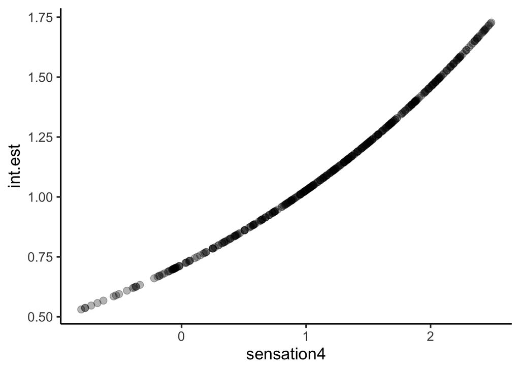

```r
ggplot(data = jpa_aug, aes(x = sensation4, y = int.est, group = as.factor(gender))) +
    geom_point(alpha = 0.3, size = 3) +
    theme(legend.position = "none")
```

#### Plot 3: Distribution of all of the interaction effect estimates

- If we absolutely had to get a *single* estimate of the interaction
  - The mean of the distribution of `int.est` values
    - Use delta method or *bootstrapping* to get CIs
    - See page 252 of McCabe et al. (2020)
  - But what does this single value mean?
    - Not the same as $b_3$ in linear regression
    - Has more to do with the sample values

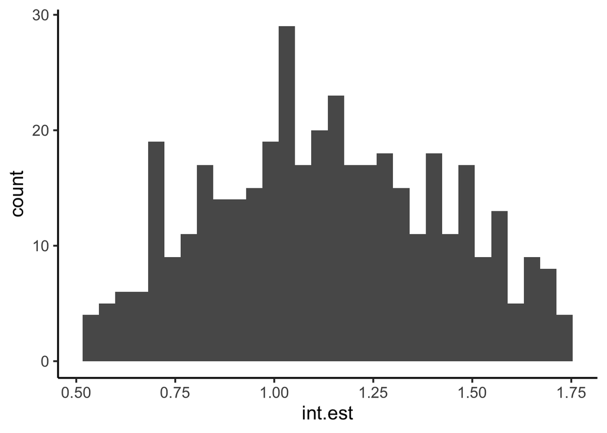

```r
ggplot(data = jpa_aug, aes(x = int.est)) +
    geom_histogram()
```

- The mean of this distribution is 1.133
  - All values of `int.est` are greater than 0
  - Use this to describe the interaction
    - “The interaction is positive for all sample values of `sensation4`”
  - See Figure 4 of MacCabe et al. (2020)

### Bootstrapping interaction effect

- This is just one way to bootstrap

```r
mean_int.est <- function(data, indices) {
    val <- data[indices,]
    return(val$int.est)
}
output <- boot(data=jpa_aug,
               statistic=mean_int.est,
               R=1000)

boot.ci(output, type = "perc")
```

```
BOOTSTRAP CONFIDENCE INTERVAL CALCULATIONS
Based on 1000 bootstrap replicates

CALL :
boot.ci(boot.out = output, type = "perc")

Intervals :
Level     Percentile
95%   ( 0.620,  1.688 )
Calculations and Intervals on Original Scale
```

## Step 3. Conditional effects

- Simple slopes are conditional effects
- Grab the coefficients from the model

```r
b0_m2 <- coefficients(m2)[1] # intercept
b1_m2 <- coefficients(m2)[2] # sensation4
b2_m2 <- coefficients(m2)[3] # gender
b3_m2 <- coefficients(m2)[4] # product term
b0_m2
```

```
(Intercept)
   0.464535
```

```r
b1_m2
```

```
sensation4
 0.1031797
```

```r
b2_m2
```

```
   gender
0.5553977
```

```r
b3_m2
```

```
sensation4:gender
        0.2143403
```

- Overall model equation (usual way)

$$\hat{\mu} = e^{0.465 + 0.103 (sensation4) + 0.555 (gender) + 0.214 (gender*sensation4)}$$

- Overall model equation (simple slopes arrangement)

$$\hat{\mu} = e^{(\color{red}{0.465 + 0.555 gender} \color{black}{) + (}\color{blue}{0.103 + 0.214 gender}\color{black}{) sensation4}}$$

- Conditional effect when `gender` = 0
  - $\hat{\mu} = e^{(\color{red}{0.465}\color{black}{) + (}\color{blue}{0.103}\color{black}{) sensation4}}$
    - RR = $e^{\color{blue}{0.103}} = 1.109$
    - For a 1 unit change in `sensation4`, the expected number of drinks for women increases by **1.109 times**
    - For a 1 unit change in `sensation4`, the expected number of drinks for women increases by **10.9 percent**
- Conditional effect when `gender` = 1
  - $\hat{\mu} = e^{(\color{red}{0.465 + 0.555}\color{black}{) + (}\color{blue}{0.103 + 0.214}\color{black}{) sensation4}} = e^{(\color{red}{1.02}\color{black}{) + (}\color{blue}{0.318}\color{black}{) sensation4}}$
    - RR = $e^{\color{blue}{0.318}} = 1.374$
    - For a 1 unit change in `sensation4`, the expected number of drinks for men increases by **1.374 times**
    - For a 1 unit change in `sensation4`, the expected number of drinks for men increases by **37.4 percent**

### Plots

- You can get `ggplot()` to plot the simple slopes automatically or manually
  - The automatic version is quick and easy
  - The manual version is helpful if you want to plot some other function (e.g., the simple slopes for the model **without** the product term, as in the lecture)

#### Automatic version

- X axis: `x = sensation4`
- Y axis: `y = y`
- `group = as.factor(gender)`
  - Everything it plots will be done separately for each gender
    - For example, lines it plots
  - `as.factor()` tells it to treat gender as a categorical variable (i.e., “factor” in R parlance) instead of a continuous variable that just happens to be 0 and 1
    - If you don’t do this, some of the options don’t work right because they only work for categorical variables
- `geom_point()` adds the observe values
  - `aes(color = as.factor(gender), shape = as.factor(gender))` makes the points different colors and different shapes depending on the value of `gender`
  - `alpha = 0.3, size = 3` makes the points transparent and larger
- `geom_smooth()` adds the lines
  - `method = "glm", method.args = list(family = "poisson")` tells it to use a Poisson GLM model for the line
  - `linewidth = 2` makes the line thicker
  - `se = FALSE` removes the standard error bands
    - You can add these back, but the plot will be busier
  - `aes(color = as.factor(gender))` makes the lines different colors depending on the value of `gender`
- We actually did this above, but I’ll put it here again

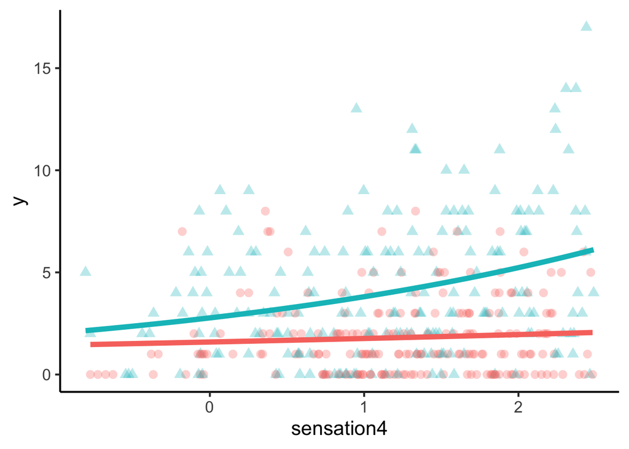

```r
ggplot(data = jpa, aes(x = sensation4, y = y, group = as.factor(gender))) +
    geom_point(aes(color = as.factor(gender), shape = as.factor(gender)),
               alpha = 0.3, size = 3) +
    geom_smooth(method = "glm", method.args = list(family = "poisson"),
                linewidth = 2, se = FALSE,
                aes(color = as.factor(gender))) +
    theme(legend.position = "none")
```

#### Manual version

- X axis: `x = sensation4`
- Y axis: `y = y`
- No `group` option: It still works if you include it, but it gives an error
- `geom_point()` adds the observe values
  - `aes(color = as.factor(gender), shape = as.factor(gender))` makes the points different colors and different shapes depending on the value of `gender`
  - `alpha = 0.3, size = 3` makes the points transparent and larger
- `geom_function()` adds the lines
  - `fun = function(x) exp(b0_m2 + b1_m2*x)` is the function you’d like to plot
    - The first one does the simple slope for `gender` = 0: $e^{b_0 + b_1 X}$
  - `fun = function(x) exp((b0_m2 + b2_m2) + (b1_m2 + b3_m2)*x)` is the second function
    - Simple slope for `gender` = 1: $e^{(b_0 + b_2) + (b_1 + b_3) X}$
  - `linewidth = 2` makes the line thicker
  - I specified the colors for each line to match the points and the lines in the other figure
    - These are the hex code values for those teal and salmon colors

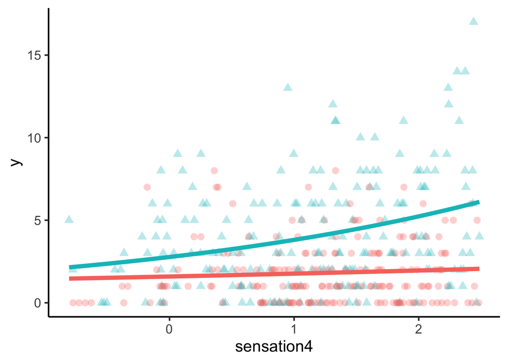

```r
ggplot(data = jpa, aes(x = sensation4, y = y)) +
    geom_point(aes(color = as.factor(gender), shape = as.factor(gender)),
               alpha = 0.3, size = 3) +
    geom_function(fun = function(x) exp(b0_m2 + b1_m2*x),
                  linewidth = 2, color = "#F8766D") +
    geom_function(fun = function(x) exp((b0_m2 + b2_m2) + (b1_m2 + b3_m2)*x),
                  linewidth = 2, color = "#00BFC4") +
    theme(legend.position = "none")
```

- Again, you could use this latter method if you wanted to plot the simple slopes for a model with no product term (i.e., no product term that modifies the slope)
  - Just all the appropriate values and plug them in

# Mediation

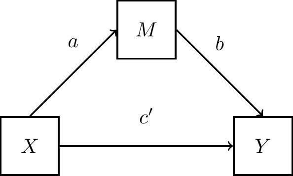

## Equations

$a$ path: $\hat{M} = i_{MX} + aX$

$b$ and $c'$ paths: $\hat{Y} = i_{YXM} + bM + c'X$

$c$ path: $\hat{Y} = i_{YX} + cX$

- *Modify each equation as need* to logistic regression, Poisson regression, etc.

## Conditional indirect effect

### $X$ to $M$

```r
xtom <- lm(sensation4 ~ gender, data = jpa)
coefficients(xtom)
```

```
(Intercept)      gender
   1.242024   -0.118866
```

```r
xtom_i <- coefficients(xtom)[1]
names(xtom_i) <- NULL
xtom_a <- coefficients(xtom)[2]
names(xtom_a) <- NULL
```

- Linear regression
  - $a$ = $-0.119$

### $M$ to $Y$

```r
mtoy <- glm(y ~ sensation4 + gender, data = jpa, family = poisson(link = "log"))
coefficients(mtoy)
```

```
(Intercept)  sensation4      gender
  0.2545520   0.2608472   0.8394682
```

```r
mtoy_i <- coefficients(mtoy)[1]
names(mtoy_i) <- NULL
mtoy_b <- coefficients(mtoy)[2]
names(mtoy_b) <- NULL
mtoy_cp <- coefficients(mtoy)[3]
names(mtoy_cp) <- NULL
```

- Poisson regression
  - $b \times e^{(i + bM + c'X)}$ = $0.261 \times e^{(0.255 + 0.261 M + 0.839 X)}$

### Conditional indirect effect

- The indirect effect is the product of the two values
- In this case, it is:
  - $a \times b \times e^{(i + bM + c'X)}$ = $-0.119 \times 0.261 \times e^{(0.255 + 0.261 M + 0.839 X)}$
- Note that it is **conditional** on both $X$ and $M$
  - Let’s break that down some
- Start with the $X$ values: 0 and 1

```r
x <- c(0, 1)
```

- What are the predicted $M$ values for each of those $X$ values?
  - Use the equation $\hat{M} = i_{MX} + aX$

```r
m <- xtom_i + xtom_a * x
```

- Now we have $X$ values and their corresponding $M$ values
- I added the $X$ and $M$ values, as well as all of the various coefficient values, to a data frame so we can calculate things

```r
med_pred <- data.frame(x, m, xtom_i, xtom_a, mtoy_i, mtoy_b, mtoy_cp)
```

- Calculate the indirect effect for each set of values

```r
med_pred$ind <- xtom_a * mtoy_b * exp(mtoy_i + mtoy_b * m + mtoy_cp * x)
med_pred
```

```
  x        m   xtom_i    xtom_a   mtoy_i    mtoy_b   mtoy_cp         ind
1 0 1.242024 1.242024 -0.118866 0.254552 0.2608472 0.8394682 -0.05529634
2 1 1.123158 1.242024 -0.118866 0.254552 0.2608472 0.8394682 -0.12411010
```

- Too many things in this table
  - Let’s just print the columns we care about: $X$, $M$, indirect effect

```r
round(med_pred[c(1:2, 8)], 3)
```

```
  x     m    ind
1 0 1.242 -0.055
2 1 1.123 -0.124
```

- Conditional indirect effects
  - **For women**, the indirect effect of `gender` to `sensation` to number of drinks is -0.055
  - **For men**, the indirect effect of `gender` to `sensation` to number of drinks is -0.124
- Compare to the “naive” indirect effect that ignores nonlinear effects
  - $a \times b = -0.119 \times 0.261 = -0.031$

### Bootstrapping indirect effect

- This is just one way to bootstrap
- EDIT: I forgot to get separate estimates for each gender
  - The **whole point** of the conditional effects here…
  - The original estimate made no sense because there was one CI for two different estimates
  - There was also a really dumb typo in the formula that was messing things up

```r
abexpib1_jpa <- function(data, indices) {
    val <- data[indices,]
    fit1 <- lm(sensation4 ~ gender, data = val)
    fit2 <- glm(y ~ sensation + gender,
                family = poisson(link = "log"),
                data = val)
    xtom_b0 <- coefficients(fit1)[1]
    xtom_b1 <- coefficients(fit1)[2]
    mtoy_b0 <- coefficients(fit2)[1]
    mtoy_b1 <- coefficients(fit2)[2]
    mtoy_b2 <- coefficients(fit2)[3]
    x <- c(0,1)
    m <- xtom_b0 + xtom_b1 * x
    indirect <- xtom_a * mtoy_b * exp(mtoy_i + mtoy_b * m + mtoy_cp * x)
    return(indirect)
}

output <- boot(data = jpa,
               statistic = abexpib1_jpa,
               R = 1000)
output
```

```
ORDINARY NONPARAMETRIC BOOTSTRAP


Call:
boot(data = jpa, statistic = abexpib1_jpa, R = 1000)


Bootstrap Statistics :
       original        bias     std. error
t1* -0.05529634  4.731885e-06 0.0007500068
t2* -0.12411010 -4.776638e-05 0.0018915036
```

```r
boot.ci(output, type = "perc", index = 1)
```

```
BOOTSTRAP CONFIDENCE INTERVAL CALCULATIONS
Based on 1000 bootstrap replicates

CALL :
boot.ci(boot.out = output, type = "perc", index = 1)

Intervals :
Level     Percentile
95%   (-0.0567, -0.0539 )
Calculations and Intervals on Original Scale
```

```r
boot.ci(output, type = "perc", index = 2)
```

```
BOOTSTRAP CONFIDENCE INTERVAL CALCULATIONS
Based on 1000 bootstrap replicates

CALL :
boot.ci(boot.out = output, type = "perc", index = 2)

Intervals :
Level     Percentile
95%   (-0.1280, -0.1203 )
Calculations and Intervals on Original Scale
```

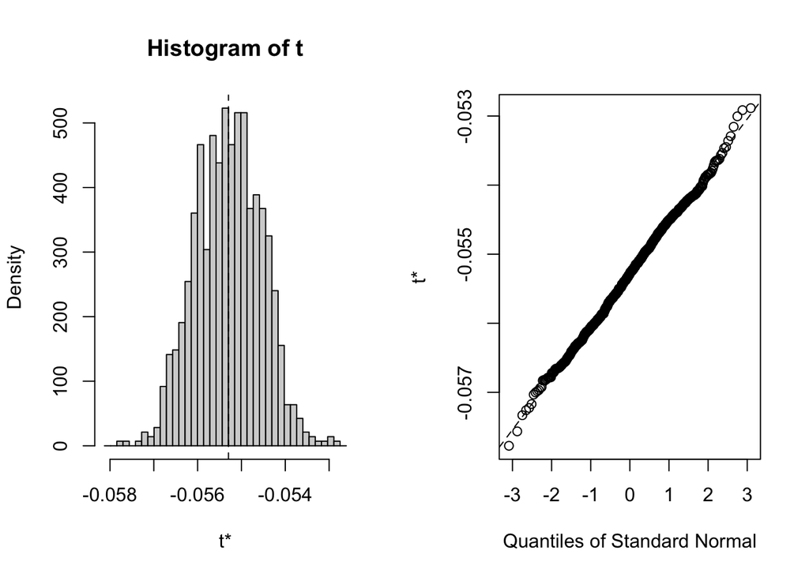

```r
plot(output, index=1)
```

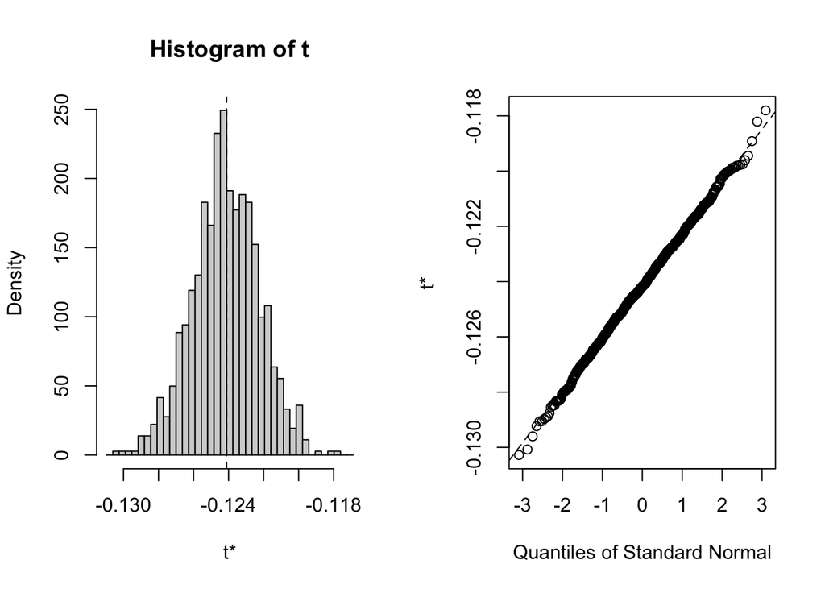

```r
plot(output, index=2)
```